# Teoria Pedagógica e Extensão Rural · Da Concepção Tradicional à Crítico-Social

Extensão Rural

Prof. Dr. Luiz Diego Vidal Santos

## Abertura Visão Geral da Aula

Roteiro da aula Tópicos principais

- 1 Educação e Extensão Rural
- 2 Concepção Tradicional (Pedagogia Bancária)
- 3 Concepção Nova (Escola Nova)
- 4 Concepção Tecnicista
- 5 Concepção Crítico-Social dos Conteúdos
- 6 Implicações para a Prática Extensionista

Objetivo central Teorias pedagógicas e modelos de ATER

Sistematizar as quatro grandes concepções pedagógicas e analisar como cada uma influencia modelos, métodos e estratégias de extensão rural, desde o difusionismo até as abordagens participativas contemporâneas.

Saviani Paulo Freire Malcolm Knowles PNATER

Toda prática extensionista carrega uma concepção pedagógica — explícita ou implícita — que define o lugar do agricultor.

## Fundamentos Educação e Extensão Rural

Freire (1983) A extensão como processo educativo

A extensão rural é, em sua essência, um **processo educativo**. Todo ato extensionista envolve relações de ensino-aprendizagem entre extensionistas e agricultores, configuradas de formas distintas conforme a concepção pedagógica subjacente.

Saviani (2008) Exigência para o agrônomo

Compreender as teorias pedagógicas não se restringe a educadores formais: é a concepção pedagógica adotada que determina se o extensionista atuará como **transmissor de pacotes tecnológicos** ou como **facilitador de processos emancipatórios**.

Dermeval Saviani organizou as correntes pedagógicas brasileiras em quatro grandes concepções, cada uma com reflexos diretos na ATER.

# As Quatro Concepções Pedagógicas

## Pedagogia Concepção Tradicional (Pedagogia Bancária)

Freire (1987) · Peixoto (2008) Transmissão vertical e difusionismo

A **pedagogia tradicional** baseia-se na transmissão vertical do professor (detentor do saber) para o aluno (receptáculo passivo), chamada por Paulo Freire (1987) de **educação bancária**.

Na extensão rural, manifestou-se no **modelo difusionista clássico**: o agricultor era visto como carente de conhecimento válido e seu saber empírico era tratado como obstáculo à modernização.

**Consequência:** exclusão de grande parcela de agricultores familiares que não se adequavam ao modelo modernizante, com perda de agrobiodiversidade e saberes tradicionais associados (Caporal e Costabeber, 2004).

Características na Extensão Rural Cinco marcas do difusionismo

1. Comunicação unidirecional (extensionista → agricultor)
2. Agricultor como receptor passivo de tecnologias
3. Saber local desvalorizado ou ignorado
4. Foco na adoção de pacotes tecnológicos
5. Avaliação pelo número de “adotantes”

## Pedagogia Concepção Nova (Escola Nova)

**Movimento escolanovista (1920–1930):** consolidado no Brasil com **Anísio Teixeira** e **Lourenço Filho**, desloca o centro do processo educativo do professor para o **aluno**, concebendo a aprendizagem como processo ativo, experiencial e centrado nos interesses do educando (Libâneo, 1994).

Pilares teóricos Princípios

- Valorização da experiência prévia do aprendiz
- Protagonismo do educando na definição dos temas de estudo
- Papel do educador como **facilitador**, não transmissor
- Ênfase em métodos ativos de aprendizagem (**aprender fazendo**)

Coelho (2014) Reflexos na Extensão Rural

- Unidades Demonstrativas em propriedades de agricultores
- Trocas de experiências entre produtores (**agricultor a agricultor**)
- Dias de campo participativos
- Valorização do **saber-fazer** do agricultor como ponto de partida da intervenção

## Pedagogia Concepção Tecnicista

Saviani (2008) Eficiência e controle

Consolidada no Brasil durante o regime militar (décadas de 1960 e 1970), prioriza a eficiência do ensino por meio da racionalização, planejamento rigoroso, definição de objetivos mensuráveis e controle de resultados.

Peixoto (2008) Modernização conservadora e EMBRATER

Alinhou-se à **modernização conservadora**: o extensionista atuava como técnico especializado avaliado por produtividade, adoção de insumos e volume de crédito rural intermediado. A **EMBRATER (1974–1990)** operou predominantemente sob essa lógica.

**Consequência:** **homogeneização** das recomendações técnicas, desconsiderando diversidades edafoclimáticas, socioeconômicas e culturais — marginalizando agricultores que não se enquadravam no modelo produtivista.

## Pedagogia Concepção Crítico-Social dos Conteúdos

Libâneo (1994) · Freire (1987) Mediação crítica e libertação

Sistematizada por **Dermeval Saviani** e **José Carlos Libâneo**, supera o conteudismo tradicional e o espontaneísmo escolanovista: conteúdos são instrumentos para compreender e transformar a realidade social, com o educador como mediador crítico.

**Paulo Freire (1987)** complementa essa visão com a **pedagogia libertadora**, pelo diálogo problematizador mútuo.

Caporal (2003) Aplicação na Extensão Rural

- Diálogo horizontal entre extensionista e agricultor
- Problematização da realidade como ponto de partida
- Construção coletiva de soluções contextualizadas
- Valorização simultânea de saber técnico-científico e saber local
- Avaliação por indicadores de transformação social, não apenas produtividade

## Pedagogia Síntese Comparativa das Concepções

| Concepção | Papel do Educador / Extensionista | Papel do Educando / Agricultor | Método Predominante | Modelo de ER Associado |
| --- | --- | --- | --- | --- |
| **Tradicional** | Transmissor | Receptor passivo | Palestra, dia de campo demonstrativo | Difusionismo clássico |
| **Escola Nova** | Facilitador | Protagonista ativo | Unidades demonstrativas, trocas | Transição |
| **Tecnicista** | Técnico especializado | Executor de receituários | Planejamento, metas, crédito | Modernização conservadora |
| **Crítico-Social** | Mediador dialógico | Co-construtor de conhecimento | DRP, pesquisa-ação, experimentação participativa | PNATER, agroecologia |

Identificar a concepção dominante revela quem decide os objetivos, como o saber circula e qual modelo de desenvolvimento é reforçado.

# Pedagogia Freiriana e Andragogia

## Freire A Pedagogia Freiriana: Extensão ou Comunicação?

Em *“Extensão ou Comunicação?”* (1983), **Paulo Freire** mostra que “extensão” carrega a ideia de **estender algo de quem sabe para quem não sabe** (lógica bancária), propondo em seu lugar a **comunicação** dialógica entre sujeitos.

01 · Sujeito Extensionista

**Sujeito cognoscente** que problematiza e escuta sem impor pacotes prontos.

02 · Encontro Diálogo Problematizador

Comunicação horizontal bidirecional entre extensionista e agricultor.

03 · Sujeito Agricultor

**Sujeito cognoscente** portador de experiência territorial e saber empírico.

04 · Síntese Realidade → Práxis

**Objeto cognoscível** transformado conjuntamente pela **práxis** (ação-reflexão).

A **práxis** freiriana (ação + reflexão) é o fundamento metodológico do DRP, da pesquisa-ação e da construção coletiva do conhecimento agroecológico.

## Andragogia Bases Pedagógicas: Knowles, Freire e Kolb

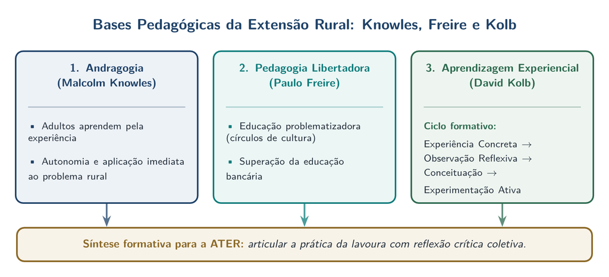

Bases pedagógicas da extensão rural articulando a Andragogia de Malcolm Knowles, a Pedagogia Libertadora de Paulo Freire e a Aprendizagem Experiencial de David Kolb.

Convergência formativa para a ATER Articular a prática da lavoura com autonomia do aprendiz adulto e reflexão crítica coletiva

Knowles (experiência adulta), Freire (problematização) e Kolb (experiência → reflexão → conceituação → ação) sustentam metodologias participativas no campo.

## Andragogia Andragogia de Knowles e Extensão Rural

Knowles (1970) Seis pilares da educação de adultos

A **andragogia** aborda especificamente a educação de adultos — perfil dos agricultores, com vasta experiência de vida e expectativas concretas de aplicação:

- **Necessidade de saber** (por que aprender)
- **Autoconceito do aprendiz** (autonomia)
- **Papel da experiência prévia**
- **Prontidão** e **orientação** para a aprendizagem
- **Motivação intrínseca**

Aplicação em ATER Conexão Andragogia e Extensão

1. Agricultores aprendem melhor quando o conteúdo resolve problemas reais
2. A experiência do agricultor é recurso pedagógico central
3. A motivação intrínseca supera incentivos externos
4. O extensionista facilita, não impõe
5. A aprendizagem deve respeitar o ritmo e a autonomia do adulto
6. O planejamento do processo educativo deve ser compartilhado

# Formação Agronômica, Conclusão e Referências

## Formação Implicações para a Formação do Agrônomo

A formação do engenheiro agrônomo não pode se limitar às competências técnico-produtivas: os pressupostos pedagógicos definem a qualidade da relação entre o profissional e os agricultores (Coelho, 2014).

Repertório do extensionista Competências pedagógicas necessárias

- Escuta ativa e diálogo intercultural
- Domínio de métodos participativos (**DRP, pesquisa-ação**)
- Planejamento de processos educativos centrados no aprendiz
- Sensibilidade para reconhecer e valorizar saberes diversos
- Reflexão crítica sobre a própria prática

Caporal e Costabeber (2004) Desafios institucionais

A institucionalidade da ATER no Brasil ainda opera fortemente sob lógicas **tecnicistas e quantitativas** (nº de visitas, laudos emitidos, produtividade), em detrimento de indicadores de empoderamento, participação e transformação social.

## Síntese Conclusão

Consciência pedagógica Teoria na prática concreta

As quatro concepções sistematizadas por Saviani (tradicional, escolanovista, tecnicista e crítico-social) manifestam-se concretamente nos modelos de extensão rural no Brasil. Reconhecê-las evita reproduções inconscientes de modelos superados e orienta práticas dialógicas e transformadoras.

PNATER · Lei 12.188/2010 Alinhamento crítico-social

A **PNATER (Lei 12.188/2010)** estabelece princípios alinhados à concepção crítico-social, mas sua efetivação depende de extensionistas pedagogicamente conscientes e de instituições que valorizem indicadores qualitativos de transformação social além dos indicadores produtivos.

## Referências Referências Bibliográficas

Pedagogia, educação e extensão Obras de referência

- COELHO, F. M. G. *A Arte das Orientações Técnicas no Campo*. Rio Branco: Suprema, 2014.
- FREIRE, P. *Extensão ou Comunicação?* Rio de Janeiro: Paz e Terra, 1983.
- FREIRE, P. *Pedagogia do Oprimido*. Rio de Janeiro: Paz e Terra, 1987.
- KNOWLES, M. S. *The Modern Practice of Adult Education*. New York: Association Press, 1970.
- LIBÂNEO, J. C. *Didática*. São Paulo: Cortez, 1994.
- SAVIANI, D. *Escola e Democracia*. Campinas: Autores Associados, 2008.

Extensão rural brasileira Agroecologia e história da ATER

- CAPORAL, F. R. *Extensão Rural Agroecológica*. Brasília: MDA, 2003.
- CAPORAL, F. R.; COSTABEBER, J. A. *Agroecologia e Extensão Rural: contribuições para o desenvolvimento rural sustentável*. Brasília: MDA/IICA, 2004.
- PEIXOTO, M. et al. *Extensão Rural no Brasil: uma abordagem histórica*. Texto para Discussão, CONLEG/Senado, 2008.